# Structure Prediction and Learning Pilot Analyses

Chiara Gambi

02/09/2022

# 1 Background

The analyses below are based on 120 children (mostly 4 year olds, but a few had already turned five at the time of testing). We actually tested 24 more children, but data for these had to be discarded after we discovered an error in the training phase for the DO NonPred condition: one of the sentence recordings (out of 12 training trials) was mistakenly in the PO form rather than the DO form. Data from these kids were discarded and we tested 20 more kids after fixing the error. Note that this means we did not counterbalance assignment of children to conditions. When I compared the findings from the 24 children originally tested on the incorrect version to those from the 20 children tested on the corrected version, no differences were noticeable. In any case, the analyses below only include data from children tested on the correct version. The error did not affect the PO Pred, PO NonPred and DO Pred training conditions. Testing took place either in the lab or at the child's nursery.

The table below shows the current number of participants in each training condition. This is not balanced at the moment.

| sentence_type | animacy | count.sum |
| --- | --- | --- |
| DO | NonPred | 25 |
| DO | Pred | 28 |
| PO | NonPred | 32 |
| PO | Pred | 35 |

## 1.1 Graphs

The graphs below show accuracy scores for pre- and post-test or difference scores (see respective tabs), separately for test trials that were more difficult (animate-animate, i.e. with an animate theme as well as an animate recipient) or easier (animate-inanimate, i.e., with an animate recipient but an inanimate theme). All test trials were in the DO form.

### 1.1.1 Pre-test vs. post-test scores

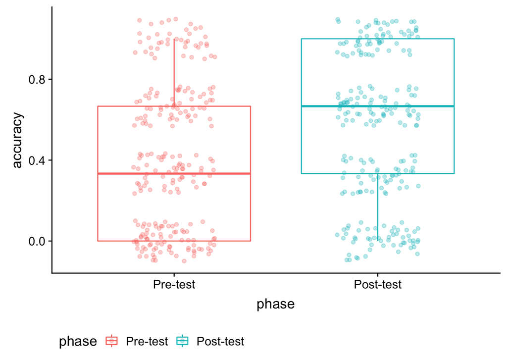

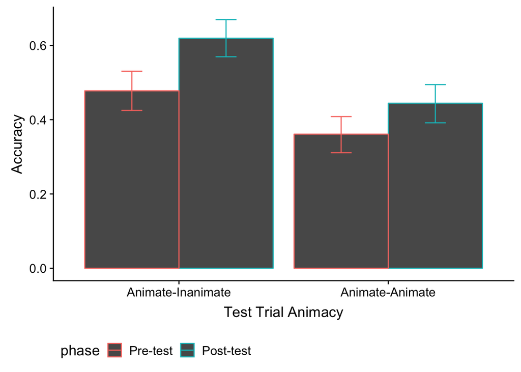

### 1.1.2 Difference scores

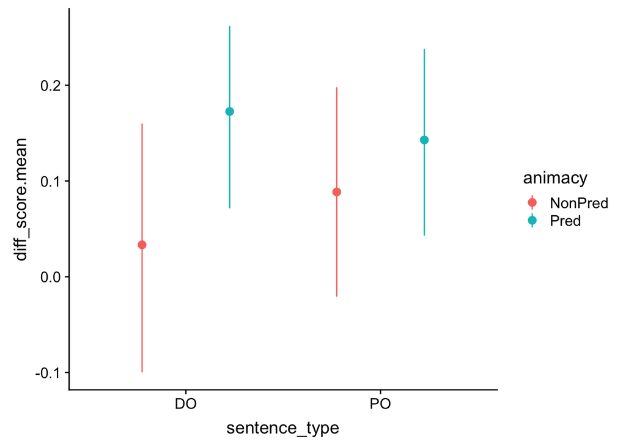

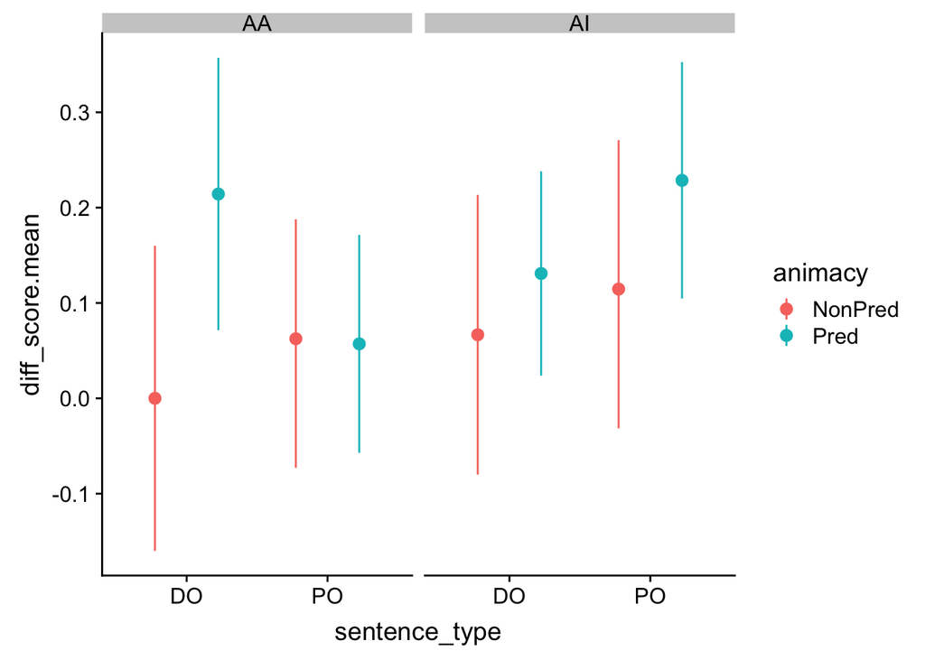

## 1.2 Analyses

Legend

| Factor Label | Gloss |
| --- | --- |
| PC | Pre-test score |
| SCC | Sentence Type (PO vs. DO) |
| ACC | Predictability (NonPred vs. Pred) |
| TACC | Animacy (AI vs. AA) |

### 1.2.1 Omnibus ANCOVA

Summary.

- main effect of pre-test accuracy -- higher accuracy in post-test if higher accuracy in pre-test
- main effect of trial animacy -- higher accuracy for AI test items
- **marginal** interaction between sentence type and trial animacy -- the advantage for AI over AA is smaller if training == DO

```
## glmer(formula = `accuracy.Post-test` ~ PC + SCC * ACC * TACC +
##     (1 | subject_id), data = all.tp.w, family = "binomial", control = glmerControl(optimizer = "bobyqa"))
```

Post-test accuracy, controlling for Pre-test accuracy - Model

|  | Estimate | Std..Error | z.value | Pr...z.. |
| --- | --- | --- | --- | --- |
| (Intercept) | 0.1590592 | 0.1626643 | 0.9778373 | 0.3281548 |
| PC | 0.6395281 | 0.2274289 | 2.8119911 | 0.0049236 |
| SCC | 0.2470149 | 0.3277574 | 0.7536517 | 0.4510584 |
| ACC | 0.4715004 | 0.3265487 | 1.4438897 | 0.1487700 |
| TACC | -0.9812987 | 0.1944485 | -5.0465734 | 0.0000004 |
| SCC:ACC | 0.7471917 | 0.6563363 | 1.1384282 | 0.2549417 |
| SCC:TACC | 0.6355942 | 0.3769359 | 1.6862130 | 0.0917548 |
| ACC:TACC | -0.1216999 | 0.3746253 | -0.3248576 | 0.7452888 |
| SCC:ACC:TACC | 0.6714098 | 0.7535614 | 0.8909821 | 0.3729388 |

### 1.2.2 Animate-Animate vs. Animate-Inanimate Test trials

Summary for AA

- main effect of pre-test accuracy -- higher accuracy in post-test if higher accuracy in pre-test
- **marginal** interaction of sentence_type and predictability -- higher accuracy if training == DO Pred

Summary for AI

- main effect of pre-test accuracy -- higher accuracy in post-test if higher accuracy in pre-test

```
## glmer(formula = `accuracy.Post-test` ~ PC + SCC * ACC + (1 |
##     subject_id), data = subset(all.tp.w, trial_animacy == "AA"),
##     family = "binomial", control = glmerControl(optimizer = "bobyqa"))
```

Post-test accuracy, controlling for Pre-test accuracy - Animate-Animate test trials only

|  | Estimate | Std..Error | z.value | Pr...z.. |
| --- | --- | --- | --- | --- |
| (Intercept) | -0.2241046 | 0.1413319 | -1.585662 | 0.1128160 |
| PC | 0.8356571 | 0.2637788 | 3.168022 | 0.0015348 |
| SCC | 0.4613675 | 0.2818282 | 1.637053 | 0.1016195 |
| ACC | 0.3406008 | 0.2797258 | 1.217624 | 0.2233669 |
| SCC:ACC | 0.9296972 | 0.5642583 | 1.647644 | 0.0994256 |

```
## glmer(formula = `accuracy.Post-test` ~ PC + SCC * ACC + (1 |
##     subject_id), data = subset(all.tp.w, trial_animacy == "AI"),
##     family = "binomial", control = glmerControl(optimizer = "bobyqa"))
```

Post-test accuracy, controlling for Pre-test accuracy - Animate-Inanimate test trials only

|  | Estimate | Std..Error | z.value | Pr...z.. |
| --- | --- | --- | --- | --- |
| (Intercept) | 0.6425374 | 0.1905323 | 3.3723280 | 0.0007454 |
| PC | 1.2116799 | 0.3135912 | 3.8638832 | 0.0001116 |
| SCC | -0.0928180 | 0.3664853 | -0.2532653 | 0.8000632 |
| ACC | 0.5333392 | 0.3650135 | 1.4611493 | 0.1439745 |
| SCC:ACC | 0.3826801 | 0.7323292 | 0.5225521 | 0.6012860 |

### 1.2.3 DO vs. PO-trained groups

Summary for DO-trained groups

- main effect of pre-test accuracy -- higher accuracy in post-test if higher accuracy in pre-test
- main effect of trial animacy -- higher accuracy for AI test items
- **marginal** main effect of animacy/predictability -- higher accuracy for participants trained on Predictable DOs than Unpredictable DOs

Summary for PO-trained groups

- **marginal** main effect of pre-test accuracy -- higher accuracy in post-test if higher accuracy in pre-test
- main effect of trial animacy -- higher accuracy for AI test items

```
## glmer(formula = `accuracy.Post-test` ~ PC + ACC * TACC + (1 |
##     subject_id), data = subset(all.tp.w, sentence_type == "DO"),
##     family = "binomial", control = glmerControl(optimizer = "bobyqa"))
```

Post-test accuracy, controlling for Pre-test accuracy - DO-trained groups only

|  | Estimate | Std..Error | z.value | Pr...z.. |
| --- | --- | --- | --- | --- |
| (Intercept) | 0.2908567 | 0.2136251 | 1.3615288 | 0.1733466 |
| PC | 0.6630247 | 0.3125260 | 2.1215027 | 0.0338795 |
| ACC | 0.8406858 | 0.4299340 | 1.9553836 | 0.0505378 |
| TACC | -0.5856080 | 0.2706433 | -2.1637630 | 0.0304825 |
| ACC:TACC | 0.2310126 | 0.5330391 | 0.4333876 | 0.6647332 |

```
## glmer(formula = `accuracy.Post-test` ~ PC + ACC * TACC + (1 |
##     subject_id), data = subset(all.tp.w, sentence_type == "PO"),
##     family = "binomial", control = glmerControl(optimizer = "bobyqa"))
```

Post-test accuracy, controlling for Pre-test accuracy - PO-trained groups only

|  | Estimate | Std..Error | z.value | Pr...z.. |
| --- | --- | --- | --- | --- |
| (Intercept) | 0.0444365 | 0.2408860 | 0.1844710 | 0.8536440 |
| PC | 0.6086732 | 0.3257946 | 1.8682730 | 0.0617240 |
| ACC | 0.1523273 | 0.4816571 | 0.3162568 | 0.7518076 |
| TACC | -1.3244169 | 0.2748872 | -4.8180379 | 0.0000014 |
| ACC:TACC | -0.4337045 | 0.5219493 | -0.8309323 | 0.4060119 |

## 1.3 Power analysis

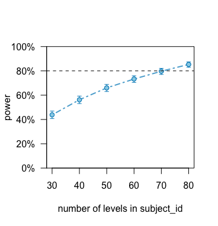

power curve, 1 observation/verb, d = 0.82

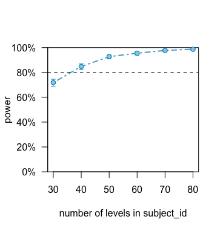

power curve, 2 observation/verb, d = 0.82

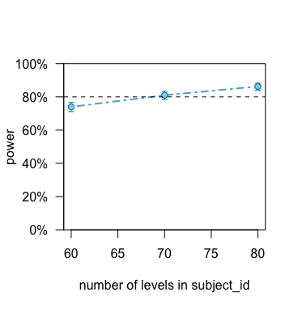

power curve, 2 observation/verb, d = 0.6

[output not shown]